# Taller Series de tiempo

Daniel Perez

2023-07-20

```r
library(astsa)
library(tseries)
```

```r
library(ggplot2)
```

## Punto 1

Considere las dos series de tiempo:
$$x_{t}=w_{t}$$
$$y_{t}=w_{t}-\theta_{t-1}+u_{t}$$
Donde $w_{t}$ y $u_{t}$ son dos series con ruido blanco con varianzas $σ_{w^{2}} = 2$ y $σ_{u^{2}} = 1$ respectivamente y $\theta=0.7$. Implemente en R un proceso estocástico para generar las dos series (con 300 observaciones cada una) y obtenga la función de autocorrelación para la serie y. Posteriormente determine la función de correlación cruzada para las series x y y. Verifique que es posible determinar correctamente si una serie lidera a la otra.

Obtenemos las series de tiempo

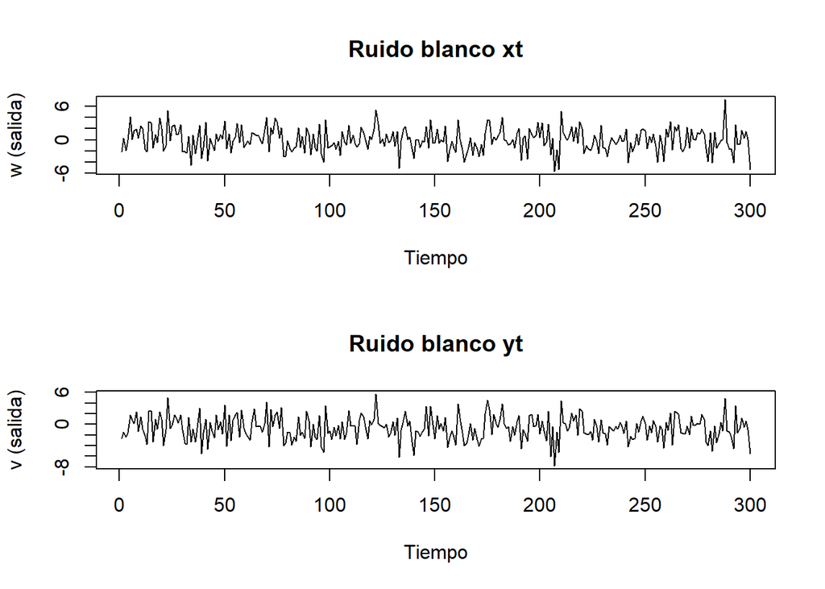

```r
w = rnorm(300,0,2)
u = rnorm(300,0,1)
x = w
y = w-0.7+u
par(mfrow=c(2,1))
plot.ts(x, main="Ruido blanco xt", xlab="Tiempo", ylab = "w (salida)")
plot.ts(y, main="Ruido blanco yt", xlab="Tiempo", ylab = "v (salida)")
```

Ahora se sacan las funciones de coorelacion

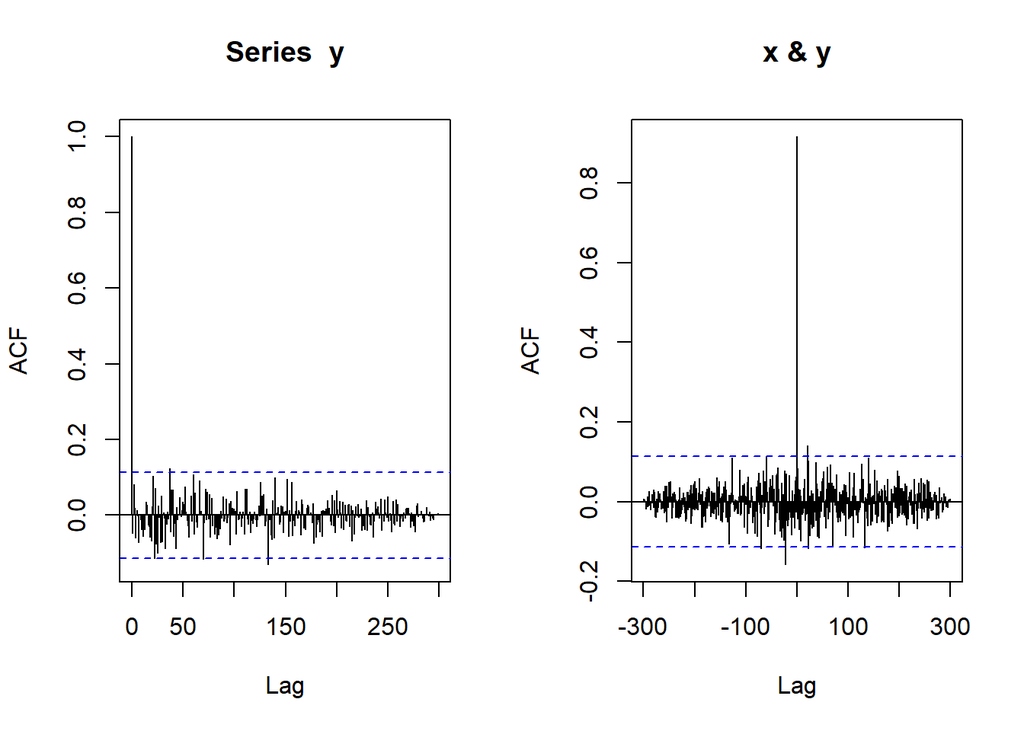

```r
par(mfrow=c(1,2))
acf_y <- acf(y, lag.max = 300, plot = TRUE)
ccf_xy <- ccf(x, y, lag.max = 300, plot = TRUE)
```

## Punto 2

Use al menos dos técnicas diferentes expuestas en la sección 2.3 “Smoothing in the Time Series Context” del libro de Shumway [1], para estimar una línea de tendencia para la serie de temperatura global (En R, para acceder a los datos utilice la librería astsa. Los datos están almacenados en la variable globtemp). Compare los resultados y comente las ventajas y desventajas de usar cada una de las técnicas.

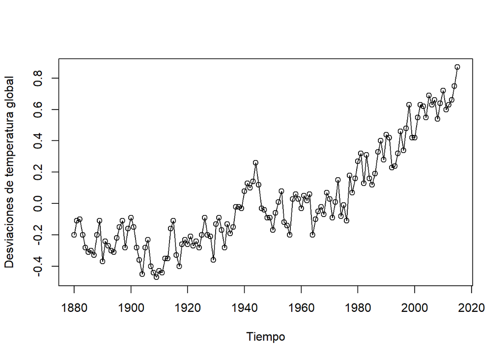

```r
plot(globtemp, type="o", ylab="Desviaciones de temperatura global", xlab='Tiempo')
```

## Punto 3

Considere las dos series de tiempo semanales de petróleo y gasolina. La serie del petróleo está en dólares por barril, mientras que la serie de gasolina está en centavos por galón (En R, para acceder a los datos utilice la librería astsa. Los datos están almacenados en las variables oil y gas).

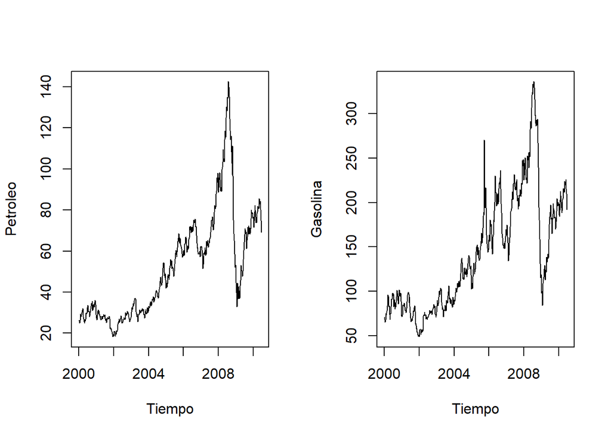

```r
serie1 = oil
serie2 = gas
par(mfrow=c(1,2))
plot(serie1, ylab="Petroleo", xlab='Tiempo')
plot(serie2, ylab="Gasolina", xlab='Tiempo')
```

1. ¿Las series son estacionarias? Comente su resultado. ¿Cómo puede probar que lo son? Realice una prueba.

```r
result_serie1 <- adf.test(serie1)
result_serie2 <- adf.test(serie2)

print("Resultados para serie1:")
```

```
## [1] "Resultados para serie1:"
```

```r
print(result_serie1)
```

```
##
##  Augmented Dickey-Fuller Test
##
## data:  serie1
## Dickey-Fuller = -3.4217, Lag order = 8, p-value = 0.04983
## alternative hypothesis: stationary
```

```r
print("Resultados para serie2:")
```

```
## [1] "Resultados para serie2:"
```

```r
print(result_serie2)
```

```
##
##  Augmented Dickey-Fuller Test
##
## data:  serie2
## Dickey-Fuller = -3.3546, Lag order = 8, p-value = 0.06127
## alternative hypothesis: stationary
```

Segun los p values obtenidos en las pruebas la serie 1 (petroleo) es estacionaria mientra que la serie 2 (Gasolina) no es estacionaria.

2. En economía, a menudo es el cambio porcentual en el precio (denominado tasa de crecimiento o retorno), en lugar del cambio de precio absoluto, lo que es importante. Utilice la transformación de la forma $y_{t} = ∇ log x_{t}$ donde $x_{t}$ es la serie de precios del petróleo o de gasolina.

```r
log_serie1 = log(serie1)
log_diff_serie1 = diff(log_serie1)

log_serie2 = log(serie2)
log_diff_serie2 = diff(log_serie2)
```

3. Grafique lado a lado los datos de petróleo y gasolina transformados en el numeral (b). ¿Qué le llama la atención?

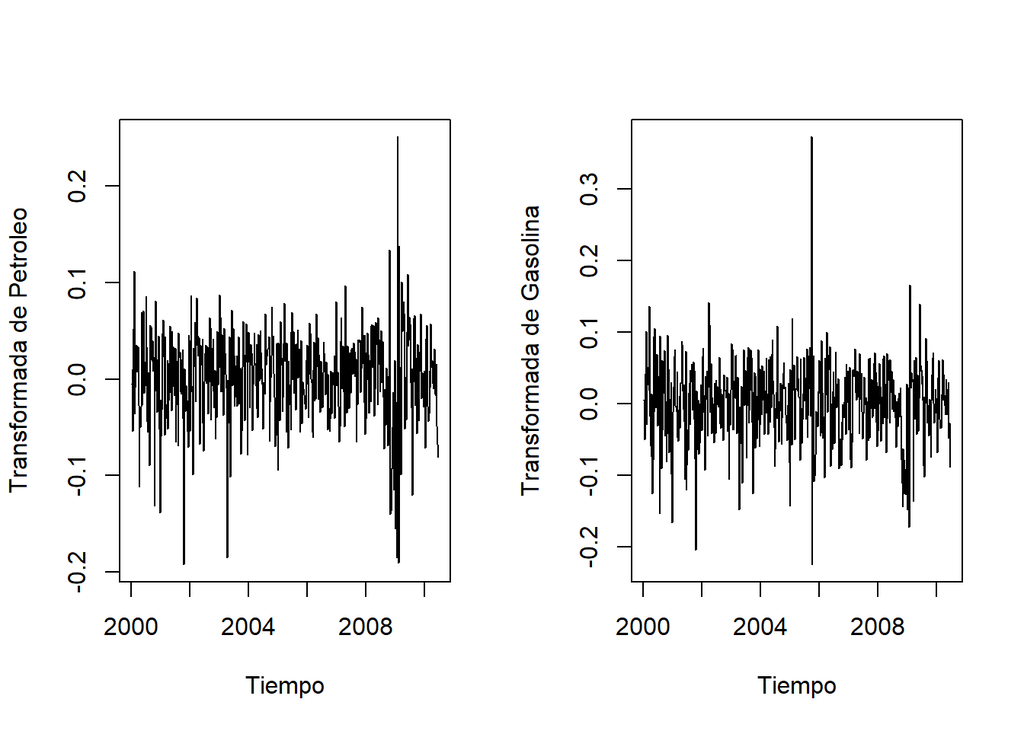

```r
par(mfrow=c(1,2))
plot(log_diff_serie1, ylab="Transformada de Petroleo", xlab='Tiempo')
plot(log_diff_serie2, ylab="Transformada de Gasolina", xlab='Tiempo')
```

Podemos observar que se estabilizaron las varianzas, ademas de que se estabilizo la tendencia.

4. Grafique los coeficientes de la función de autocorrelación simple (ACF) para los datos transformados de las dos series. Comente los resultados

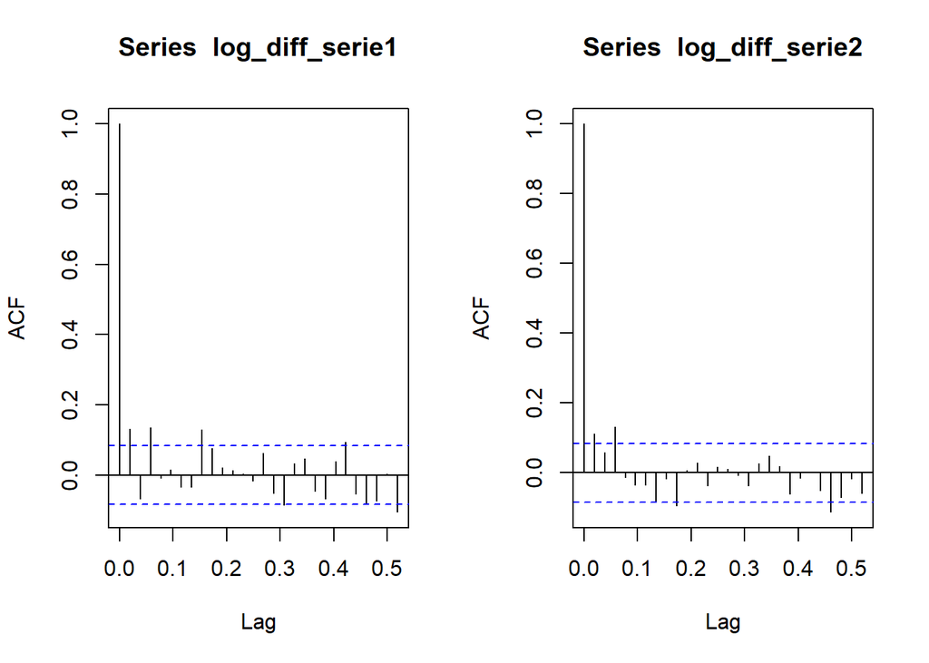

```r
par(mfrow=c(1,2))
acf_result1 <- acf(log_diff_serie1)
acf_result2 <- acf(log_diff_serie2)
```

5. Grafique la función de autocorrelación cruzada de las dos series transformadas, y comente si existen valores significativos en los coeficientes. ¿Los precios del gas lideran el precio del petróleo?

```r
autorelacion <- ccf(log_diff_serie1, log_diff_serie2)
```

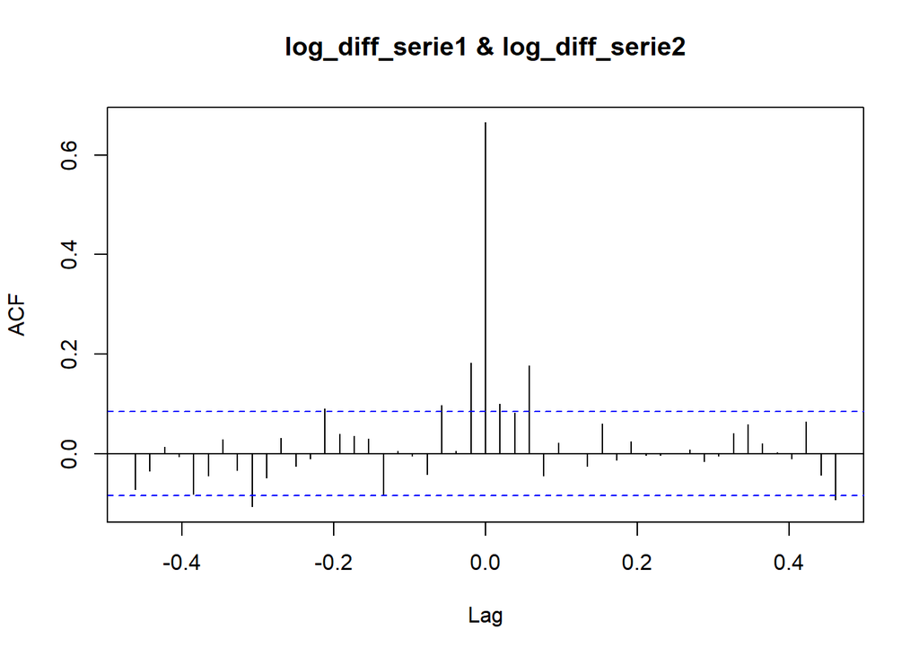

Los valores significativos que sobre salen son los del petroleo por ende el precio del petroleo lidera el precio de la gasolina